# Decision Tree

Machine Learning

R code using Various Packages for Decision Tree

Yeongeun Jeon , Jeongwook Lee , Jung In Seo  
09-25-2020

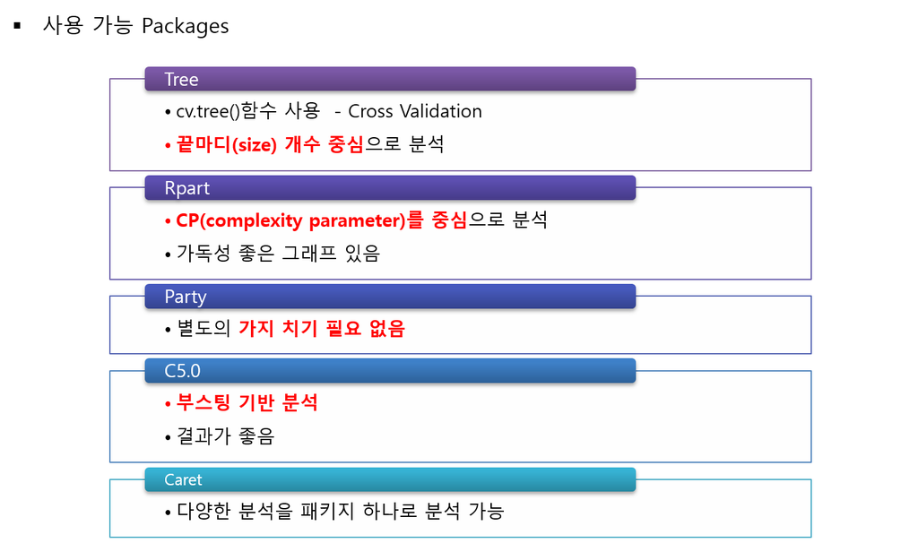

> “rpart”와 “C5.0” 방법으로 의사결정나무모형을 실습하기 위해서 사용될 예제 데이터는 “Universal Bank_Main”로 유니버셜 은행의 고객들에 대한 데이터(출처 : Data Mining for Business Intelligence, Shmueli et al. 2010)이다. 데이터는 총 2500개이며, 변수의 갯수는 13개이다. 여기서 **Target**은 `Person.Loan`이다.

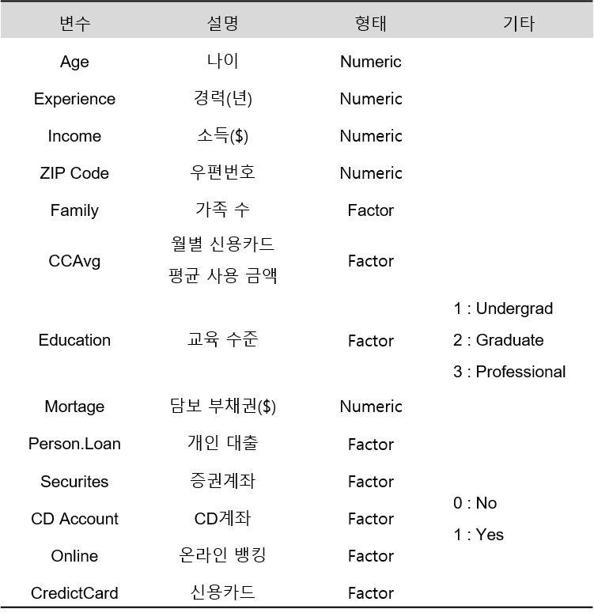

# **1. 데이터 불러오기**

```
pacman::p_load("data.table",
               "dplyr")


UB   <- fread(paste(getwd(),"Universal Bank_Main.csv", sep="/")) %>%   # 데이터 불러오기
    data.frame() %>%                                                   # Data frame 변환환
    select(-1)                                                         # ID변수 제거거


# select columns
cols <- c("Family", "Education", "Personal.Loan", "Securities.Account",
          "CD.Account", "Online", "CreditCard")
UB   <- UB %>%
    mutate_at(cols, as.factor)                                         # 범주형 변수 변환

glimpse(UB)                                                            # 데이터 구조
```

```
Rows: 2,500
Columns: 13
$ Age                <int> 25, 45, 39, 35, 35, 37, 53, 50, 35, 34, 6~
$ Experience         <int> 1, 19, 15, 9, 8, 13, 27, 24, 10, 9, 39, 5~
$ Income             <int> 49, 34, 11, 100, 45, 29, 72, 22, 81, 180,~
$ ZIP.Code           <int> 91107, 90089, 94720, 94112, 91330, 92121,~
$ Family             <fct> 4, 3, 1, 1, 4, 4, 2, 1, 3, 1, 4, 3, 2, 4,~
$ CCAvg              <dbl> 1.6, 1.5, 1.0, 2.7, 1.0, 0.4, 1.5, 0.3, 0~
$ Education          <fct> 1, 1, 1, 2, 2, 2, 2, 3, 2, 3, 3, 2, 3, 2,~
$ Mortgage           <int> 0, 0, 0, 0, 0, 155, 0, 0, 104, 0, 0, 0, 0~
$ Personal.Loan      <fct> 0, 0, 0, 0, 0, 0, 0, 0, 0, 1, 0, 0, 0, 0,~
$ Securities.Account <fct> 1, 1, 0, 0, 0, 0, 0, 0, 0, 0, 0, 0, 1, 0,~
$ CD.Account         <fct> 0, 0, 0, 0, 0, 0, 0, 0, 0, 0, 0, 0, 0, 0,~
$ Online             <fct> 0, 0, 0, 0, 0, 1, 1, 0, 1, 0, 0, 1, 0, 1,~
$ CreditCard         <fct> 0, 0, 0, 0, 1, 0, 0, 1, 0, 0, 0, 0, 0, 0,~
```

# **2. 데이터 분할**

```
# Partition (Traning Data : Test Data = 7:3)

pacman::p_load("caret")

y      <- UB$Personal.Loan                            # Target

set.seed(200)
ind    <- createDataPartition(y, p=0.7, list=T)       # Training Data를 70%로 추출
UB.trd <- UB[ind$Resample1,]                          # Traning Data

UB.ted <- UB[-ind$Resample1,]                         # Test Data

detach(package:caret)
```

# **3. R Package “rpart”**

의사결정나무모형을 형성하기 위해 사용될 첫번째 Package는 `"rpart"`이다. `"rpart"`는 약간 수정된 CART를 사용하며, CP (Complexity Parameter)를 중심으로 분석한다. 게다가 `"rpart"`는 Cross Validation을 이용하여 최적의 CP값을 선택할 수 있도록하며, defalut값은 10-fold Cross Validation이다. 또한 가독성 좋은 그래프가 있기 때문에 트리를 시각화하기에 좋다.

```
rpart(formula, data, method, ...)
```

- `formula` : Target과 예측 변수에 대한 공식으로써 일반적으로 Target ~ 예측변수로 적는다.
- `data` : `formula`의 변수들이 있는 데이터 프레임
- `method` : Target이 범주형이면 “class”, Target이 수치형이면 “anova”를 해준다.

## **3-1. 모형 적합**

```
pacman::p_load("rpart",                   # for Decision tree
               "rattle", "rpart.plot")    # for fancyRpartPlot(가독성 좋은 그래프) )

set.seed(200)                             # seed 고정 for cross-validation
rContol      <- rpart.control(xval=15)    # xval : Number of cross validation
UB.trd.rtree <- rpart(Personal.Loan~., data=UB.trd,
                      method="class", control = rContol)

summary(UB.trd.rtree)
```

```
Call:
rpart(formula = Personal.Loan ~ ., data = UB.trd, method = "class",
    control = rContol)
  n= 1751

          CP nsplit rel error    xerror       xstd
1 0.32500000      0 1.0000000 1.0000000 0.07060066
2 0.15000000      2 0.3500000 0.4111111 0.04676994
3 0.01944444      3 0.2000000 0.1944444 0.03253697
4 0.01111111      5 0.1611111 0.2166667 0.03430588
5 0.01000000      7 0.1388889 0.2055556 0.03343418

Variable importance
    Income  Education     Family      CCAvg CD.Account   Mortgage
        29         28         20         13          5          3
  ZIP.Code        Age Experience
         1          1          1

Node number 1: 1751 observations,    complexity param=0.325
  predicted class=0  expected loss=0.1027984  P(node) =1
    class counts:  1571   180
   probabilities: 0.897 0.103
  left son=2 (1366 obs) right son=3 (385 obs)
  Primary splits:
      Income     < 106.5   to the left,  improve=94.968130, (0 missing)
      CCAvg      < 2.95    to the left,  improve=69.046700, (0 missing)
      CD.Account splits as  LR,          improve=41.226300, (0 missing)
      Mortgage   < 293.5   to the left,  improve=14.467750, (0 missing)
      Education  splits as  LRR,         improve= 7.681315, (0 missing)
  Surrogate splits:
      CCAvg      < 3.25    to the left,  agree=0.868, adj=0.400, (0 split)
      Mortgage   < 339.5   to the left,  agree=0.802, adj=0.101, (0 split)
      CD.Account splits as  LR,          agree=0.786, adj=0.026, (0 split)

Node number 2: 1366 observations,    complexity param=0.01111111
  predicted class=0  expected loss=0.01537335  P(node) =0.7801256
    class counts:  1345    21
   probabilities: 0.985 0.015
  left son=4 (1277 obs) right son=5 (89 obs)
  Primary splits:
```

[output cut: 109 more lines]

```

Node number 15: 118 observations
  predicted class=1  expected loss=0  P(node) =0.06739006
    class counts:     0   118
   probabilities: 0.000 1.000

Node number 28: 13 observations
  predicted class=0  expected loss=0.2307692  P(node) =0.007424329
    class counts:    10     3
   probabilities: 0.769 0.231

Node number 29: 12 observations
  predicted class=1  expected loss=0.25  P(node) =0.006853227
    class counts:     3     9
   probabilities: 0.250 0.750
```

먼저 첫번째로 나오는 Table에 대한 용어 설명이다.

- `CP` : Complexity Parameter로 Training Data에 대한 오분류율+나무 크기에 대한 벌점 요인으로 계산된다. 또한 CP는 나무의 복잡도를 나타냄으로써 나무의 크기를 통제하고 최적의 크기를 선택할 수 있게 해준다.
- `nsplit` : 분리의 횟수
- `rel error` : $1-R^2$ root mean square error로 모형을 추정하는 데 사용된 데이터의 예측에 대한 오차
- `xerror` : Cross-validation error
- `xstd` : `xerror`의 표준오차

`Variable importance`는 변수중요도로써, Income $>$ Education $>$ Family 임을 알 수 있다. `Node number 1` 은 첫번째 노드에 대한 설명으로써 총 1751개의 관측값이 있으며, `predicted class`=0, `cp`=0.325, `expected loss (불순도)`= 0.1027984이다. 전체 관측값 1751개 중 클래스 “0”은 1571, 클래스 “1”은 180개 이며, 비율은 각각 0.897, 0.103이다. `left son = 2 (1366 obs)`는 왼쪽 자식 노드의 번호는 2 이고 1366개의 관측값이 있다는 뜻이다.

## **3-2. Tree 그림**

### **3-2-1. “Plot”**

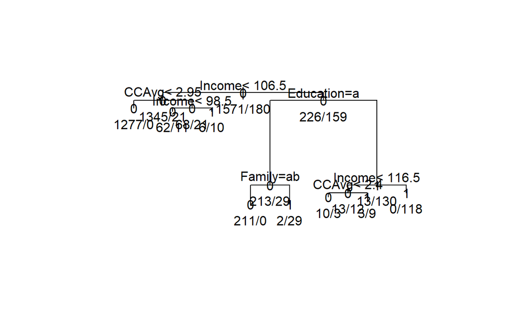

```
plot(UB.trd.rtree, branch=1, margin=0.2)
text(UB.trd.rtree, all=T, use.n=T)
```

### **3-2-2. “fancyRpartPlot”**

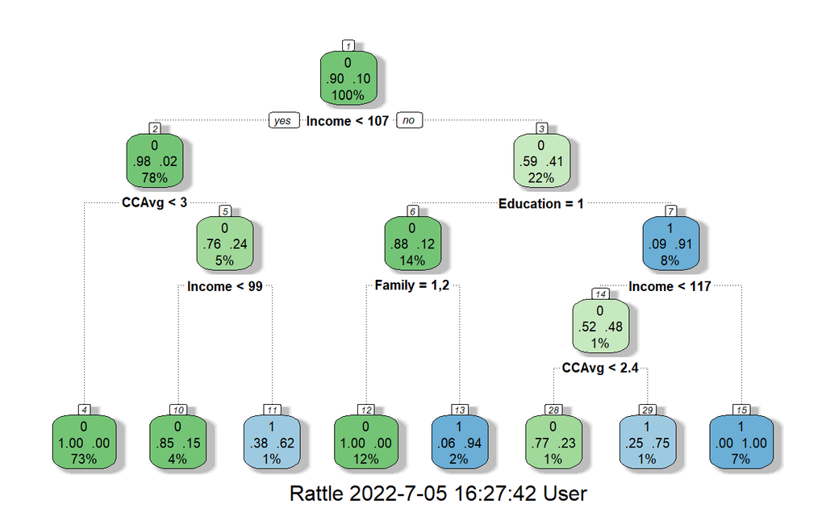

```
fancyRpartPlot(UB.trd.rtree) # 가독성 좋은 그래프래프
```

### **3-2-3. “visTree”**

```
pacman::p_load("visNetwork","sparkline")  # 네트워크 기반 그래프
visTree(UB.trd.rtree)
```

[interactive chart not shown]

## **3-3. 가지치기(과적합 문제 해결)**

과적합 문제를 해결하기 위해 가지치기를 수행한다. `rpart`에서 최적의 `cp` 값을 찾는 것이 중요하며, 이것은 `xerror`가 최소가 되는 `cp`를 찾으면 된다.

```
table              <- UB.trd.rtree$cptable             # cp Table

low.error          <- which.min(table[ ,"xerror"])     # table의 ”xerror”열에서 가장 낮은 값 위치 추출치 추출
cp.best            <- table[low.error, "CP"]           # ”CP”에서 low.error에 해당하는 cp 선택 선택

UB.trd.prune.rtree <- prune(UB.trd.rtree, cp=cp.best)  # prune(트리모형, 최적의 “CP”)
UB.trd.prune.rtree$cptable                             # 최종 모형에 대한 cp tableNA
```

```
          CP nsplit rel error    xerror       xstd
1 0.32500000      0      1.00 1.0000000 0.07060066
2 0.15000000      2      0.35 0.4111111 0.04676994
3 0.01944444      3      0.20 0.1944444 0.03253697
```

가지치기를 함으로써 최종 모형이 완성되고 최종 모형에 대한 Tree 그림은 다음과 같다.

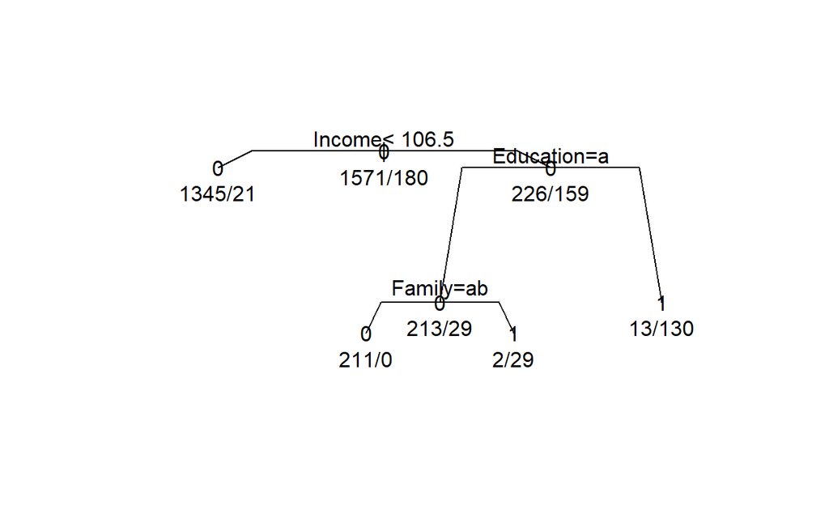

```
plot(UB.trd.prune.rtree, branch=0.8, margin=0.2)
text(UB.trd.prune.rtree, all=T, use.n=T)
```

[figure not shown]

```
fancyRpartPlot(UB.trd.prune.rtree)        # 가독성 좋은 그래프
```

```
visTree(UB.trd.prune.rtree)   # 네트워크 기반 그래프
```

[interactive chart not shown]

## **3-4. 모형 평가**

[output not shown]

### **3-4-1. ConfusionMatrix**

```
pacman::p_load("caret")

CM   <- confusionMatrix(test.rtree, UB.ted$Personal.Loan, positive="1")  # confusionMatrix(예측 클래스, 실제 클래스, positive="관심클래스")심클래스")

CM
```

```
Confusion Matrix and Statistics

          Reference
Prediction   0   1
         0 656  12
         1  17  64

               Accuracy : 0.9613
                 95% CI : (0.9449, 0.9739)
    No Information Rate : 0.8985
    P-Value [Acc > NIR] : 1.228e-10

                  Kappa : 0.7937

 Mcnemar's Test P-Value : 0.4576

            Sensitivity : 0.84211
            Specificity : 0.97474
         Pos Pred Value : 0.79012
         Neg Pred Value : 0.98204
             Prevalence : 0.10147
         Detection Rate : 0.08545
   Detection Prevalence : 0.10814
      Balanced Accuracy : 0.90842

       'Positive' Class : 1
```

```
detach(package:caret)
```

### **3-4-2. ROC 곡선**

#### **1) Package “pROC”**

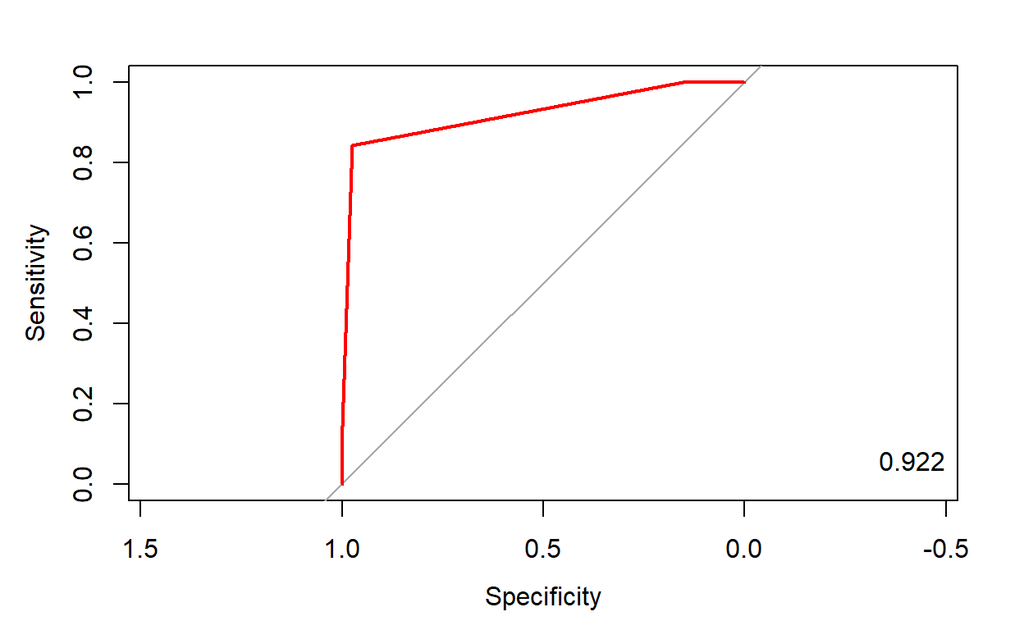

[output not shown]

```
detach(package:pROC)
```

#### **2) Package “Epi”**

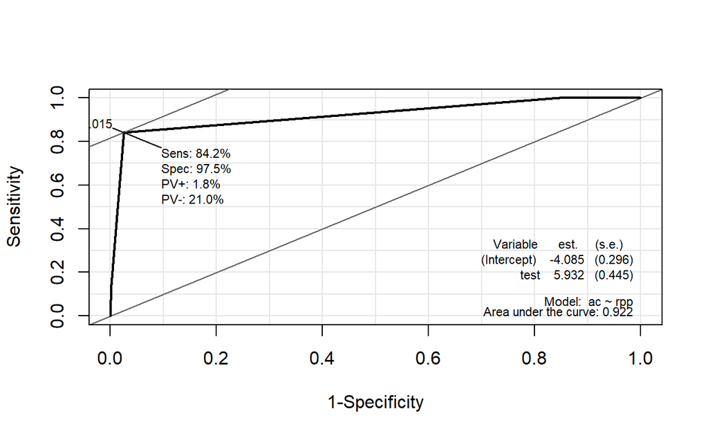

```
pacman::p_load("Epi")
# install_version("etm", version = "1.1", repos = "http://cran.us.r-project.org")

ROC(rpp, ac, plot="ROC")   # ROC(예측 확률, 실제 클래스) / 최적의 cutoff value 예측 가능
```

```
detach(package:Epi)
```

#### **3) Package “ROCR”**

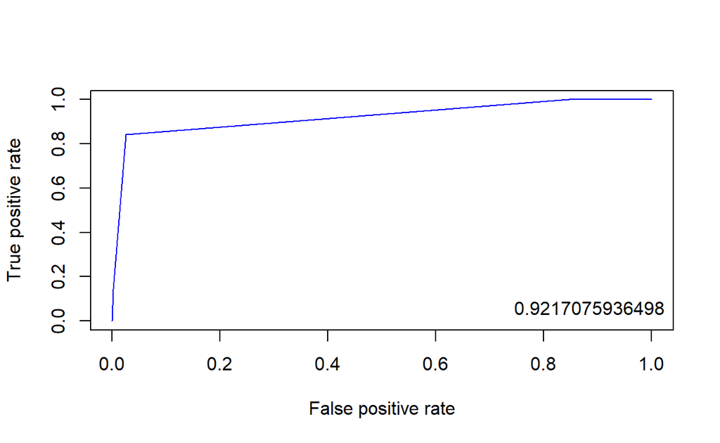

```
pacman::p_load("ROCR")

rtree.pred <- prediction(test.rtree.prob, UB.ted$Personal.Loan)    # prediction(예측 확률, 실제 클레스)

rtree.perf <- performance(rtree.pred, "tpr", "fpr")                # performance(, "민감도", "1-특이도")
plot(rtree.perf, col="blue")                                       # ROC Curve

perf.auc   <- performance(rtree.pred, "auc")                       # AUC
auc        <- attributes(perf.auc)$y.values
legend("bottomright", legend=auc, bty="n")
```

### **3-4-3. 향상 차트**

#### **1) Package “ROCR”**

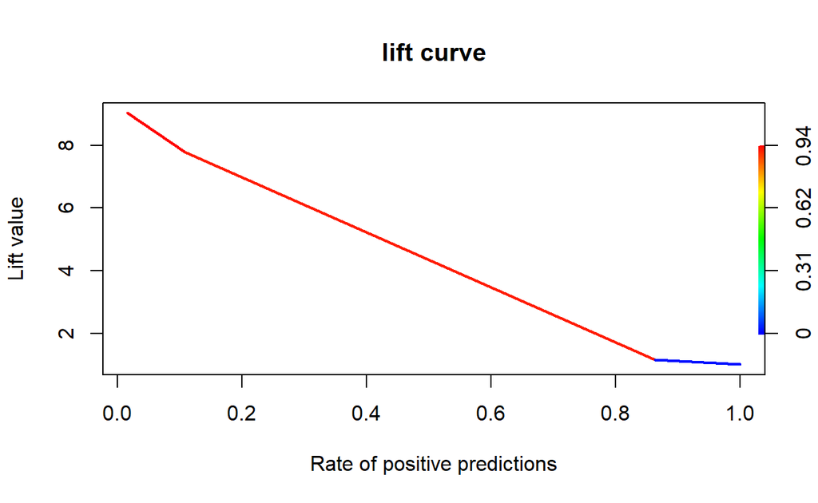

```
rtree.perf <- performance(rtree.pred, "lift","rpp")                # Lift Chart
plot(rtree.perf, main="lift curve", colorize=T, lwd=2)
```

```
detach(package:ROCR)
```

#### **2) Package “lift”**

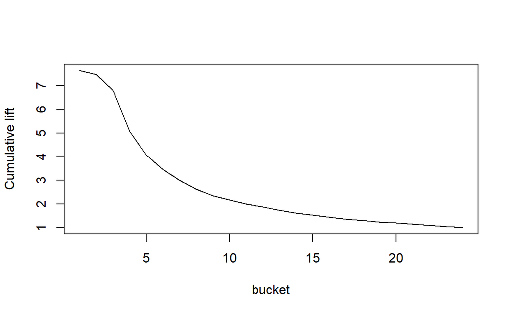

```
pacman::p_load("lift")

plotLift(test.rtree.prob, UB.ted$Personal.Loan, cumulative = T, n.buckets = 24) # plotLift(예측 확률, 실제 클래스)스)
```

```
TopDecileLift(test.rtree.prob, UB.ted$Personal.Loan)                            # Top 10% 향상도 출력
```

```
[1] 7.753
```

```
detach(package:lift)
```

# **4. R Package “C50”**

의사결정나무모형을 형성하기 위해 사용될 두번째 Package는 `"C50"`이다. `"C50"`은 앙상블 기법 중 부스팅을 이용하는데, 부스팅이란 붓스트랩 샘플을 독립적으로 복원 추출한 다수의 붓스트랩 트리를 하나씩 순차적으로 업그레이드하여 다음 트리에 가중치를 주는 방식으로 학습하는 방법이다.

```
C5.0(x, y, trials = 1, ...)
```

- `x` : 예측 변수
- `y` : Target
- `trials` : 부스팅 횟수

## **4-1. 모형 적합**

[output not shown]

```
Call:
C5.0.default(x = UB.trd[-9], y = UB.trd$Personal.Loan, trials = 1)

Classification Tree
Number of samples: 1751
Number of predictors: 12

Tree size: 8

Non-standard options: attempt to group attributes
```

- `Number of samples` : UB.trd의 개수
- `Number of predictor`s : UB.trd의 독립변수 개수
- `Tree size` : 트리 크기

## **4-2. Tree 그림**

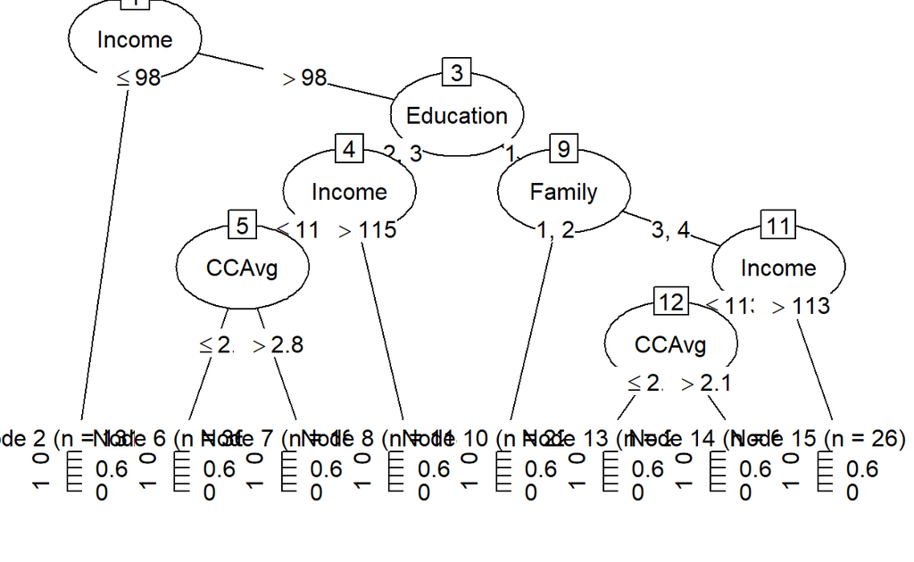

```
plot(tree)
```

## **4-3. 최적의 부스팅 횟수**

`"C5.0"`에서 가장 중요한 것은 최적의 부스팅 횟수를 찾는 것이다. 아래의 코드는 부스팅 횟수를 1~100회로 늘리면서 각 부스팅 횟수에 대해 정확도를 구한 후 정확도가 가장 높은 부스팅 횟수를 찾는 방법이다.

[output not shown]

```
[1] 10
```

```
[1] 0.9839786
```

정확도가 가장 높은 값으로 다시 `C5.0` 함수를 이용하여 최종 모형을 구한다.

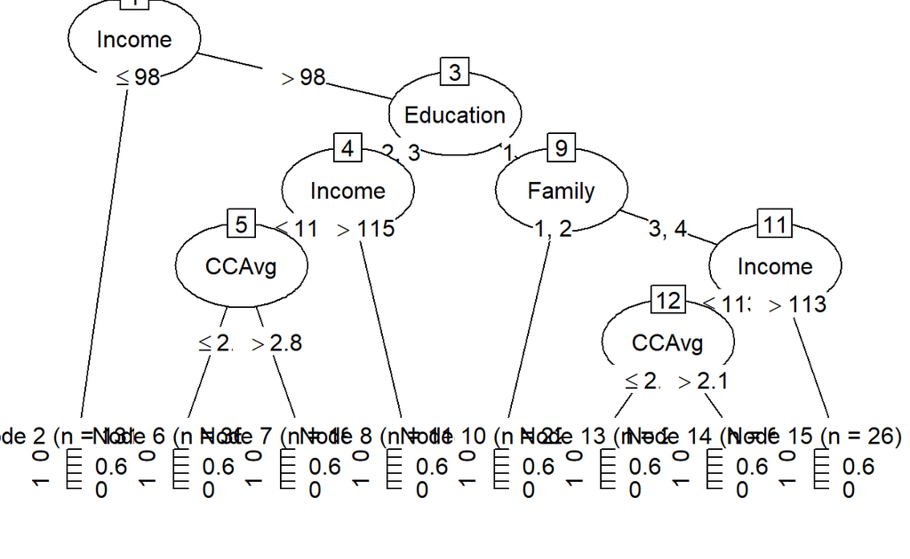

[output not shown]

## **4-4. 모형 평가**

[output not shown]

### **4-4-1. ConfusionMatrix**

```
pacman::p_load("caret")

CM      <- confusionMatrix(test.10, UB.ted$Personal.Loan, positive="1")  # confusionMatrix(예측 클래스, 실제 클래스, positive="관심클래스")심클래스")

CM
```

```
Confusion Matrix and Statistics

          Reference
Prediction   0   1
         0 669   8
         1   4  68

               Accuracy : 0.984
                 95% CI : (0.9722, 0.9917)
    No Information Rate : 0.8985
    P-Value [Acc > NIR] : <2e-16

                  Kappa : 0.91

 Mcnemar's Test P-Value : 0.3865

            Sensitivity : 0.89474
            Specificity : 0.99406
         Pos Pred Value : 0.94444
         Neg Pred Value : 0.98818
             Prevalence : 0.10147
         Detection Rate : 0.09079
   Detection Prevalence : 0.09613
      Balanced Accuracy : 0.94440

       'Positive' Class : 1
```

```
detach(package:caret)
```

### **4-4-2. ROC 곡선**

#### **1) Package “pROC”**

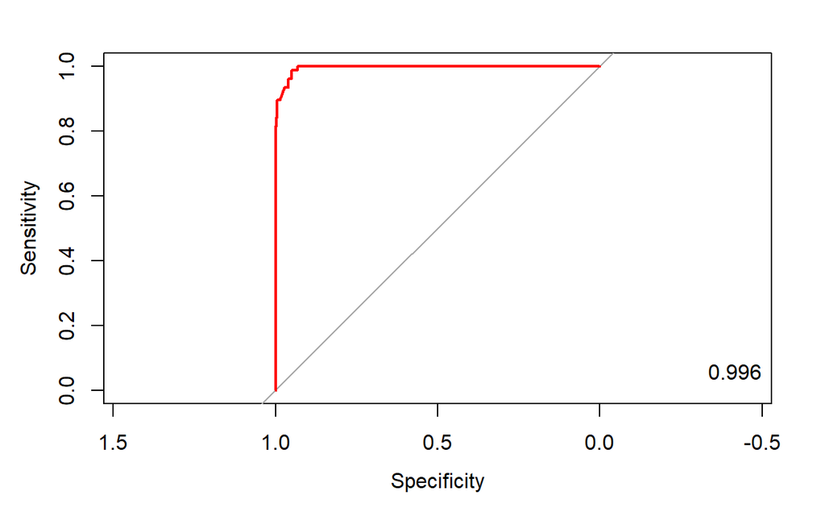

[output not shown]

```
detach(package:pROC)
```

#### **2) Package “Epi”**

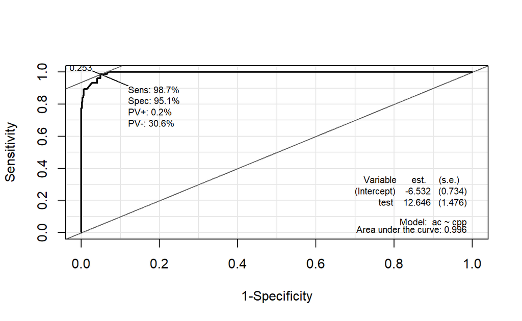

```
pacman::p_load("Epi")
# install_version("etm", version = "1.1", repos = "http://cran.us.r-project.org")

ROC(cpp, ac, plot="ROC")   # ROC(예측 확률, 실제 클래스) / 최적의 cutoff value 예측 가능
```

```
detach(package:Epi)
```

#### **3) Package “ROCR”**

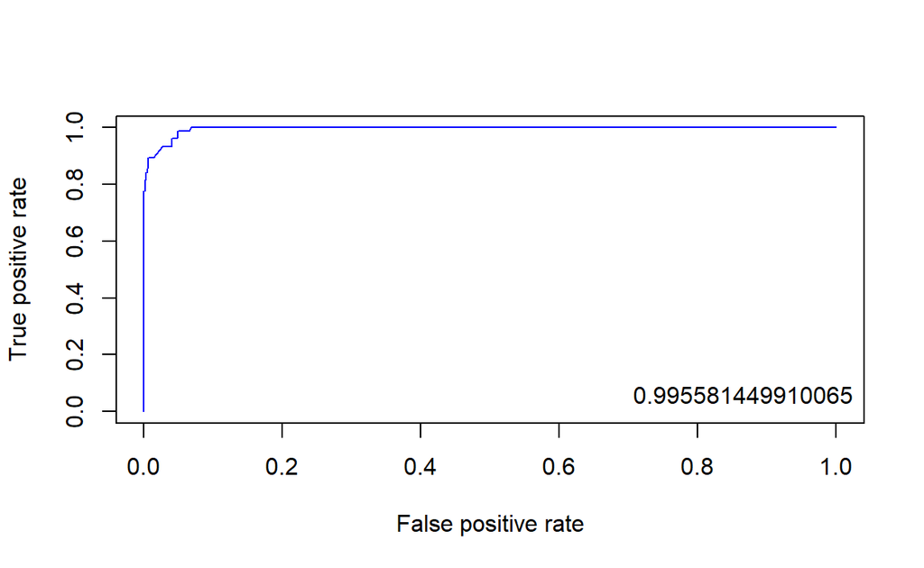

```
pacman::p_load("ROCR")

ctree.pred <- prediction(test.10.prob, UB.ted$Personal.Loan)       # prediction(예측 확률, 실제 클레스)

ctree.perf <- performance(ctree.pred, "tpr", "fpr")                # performance(, "민감도", "1-특이도")
plot(ctree.perf, col="blue")                                       # ROC Curve

perf.auc   <- performance(ctree.pred, "auc")                       # AUC
auc        <- attributes(perf.auc)$y.values
legend("bottomright", legend=auc, bty="n")
```

### **4-4-3. 향상 차트**

#### **1) Package “ROCR”**

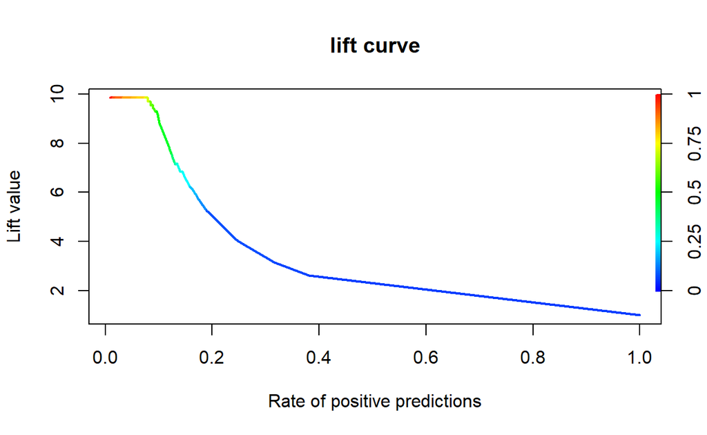

```
ctree.perf <- performance(ctree.pred, "lift","rpp")                # Lift Chart
plot(ctree.perf, main="lift curve", colorize=T, lwd=2)
```

#### **2) Package “lift”**

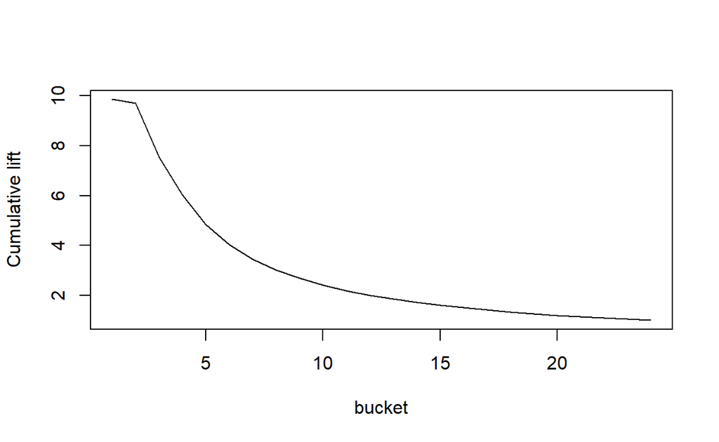

```
pacman::p_load("lift")

plotLift(test.10.prob, UB.ted$Personal.Loan, cumulative = T, n.buckets = 24) # plotLift(예측 확률, 실제 클래스)스)
```

```
TopDecileLift(test.10.prob, UB.ted$Personal.Loan)      # Top 10% 향상도 출력
```

```
[1] 8.935
```

```
detach(package:lift)
```

# **5. 모형 비교**

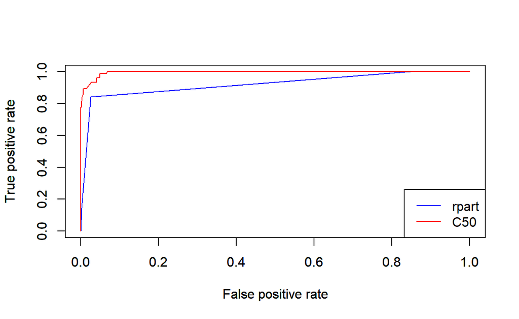

```
pacman::p_load("ROCR")

rtree.pred <- prediction(test.rtree.prob, UB.ted$Personal.Loan)    # prediction(예측 확률, 실제 클레스)

rtree.perf <- performance(rtree.pred, "tpr", "fpr")                # performance(, "민감도", "1-특이도")
plot(rtree.perf, col="blue")                                       # ROC Curve
par(new=TRUE)
ctree.perf <- performance(ctree.pred, "tpr", "fpr")                # performance(, "민감도", "1-특이도")
plot(ctree.perf, col="red")                                        # ROC Curve
legend("bottomright", legend=c("rpart","C50"), col=c("blue", "red"), lty=c(1,1))
```

```
detach(package:ROCR)
```